# Projekt 1

Dorota Łępicka, Paulina Popiołek, Agnieszka Pszczółkowska

10 listopada 2016

### Cel projektu

Celem naszego projektu było dokonanie analizy nieobecności posłów w poszczególnych klubach podczas głosowań w sejmie w trakcie 8 kadencji (dane z okresu 12. 11. 2015 r. - 04. 10. 2016 r.). W tym czasie odbyło się 1912 głosowań. Każda kropka na wykresie odpowiada jednemu politykowi.

### Analizowane dane

Do analizy użyłyśmy danych dotyczących głosowań poszczególnych posłów w okresie od 12. 11. 2015 r. do 04. 10. 2016 r.. Rozważałyśmy posłów, którzy posiadali mandat poselski w dniu 04. 10. 2016 r., pozostałych odrzuciłyśmy z analizy. Pojawiły się także przypadki posłów (11 osób), którzy w rozważanym okresie zmieniali klub. W tym wypadku przypisałyśmy im klub według stanu z dnia 04. 10. 2016 r., a liczbę nieobecności podczas głosowań zsumowałyśmy. Dodatkowo przedstawiłyśmy ich nieobecności na wykresie 3, w zależności od aktualnej przynależności do poszczególnych klubów. Ponadto wyodrębniłyśmy grupę posłów ze 100% frekwencją podczas głosowań.

### Wykres 1

Warto zwrócić uwagę na nierównomierny rozkład liczby posłów w poszczególnych klubach. Niektóre z klubów mają tylko kilku członków, co ma swoje konsekwencje w wyznaczonych statystykach nieobecności, umieszczonych na kolejnym wykresie. Liczbę mandatów w poszczególnych klubach przedstawia poniższy wykres. Kolory odpowiadają barwom poszczególnych klubów poselskich.

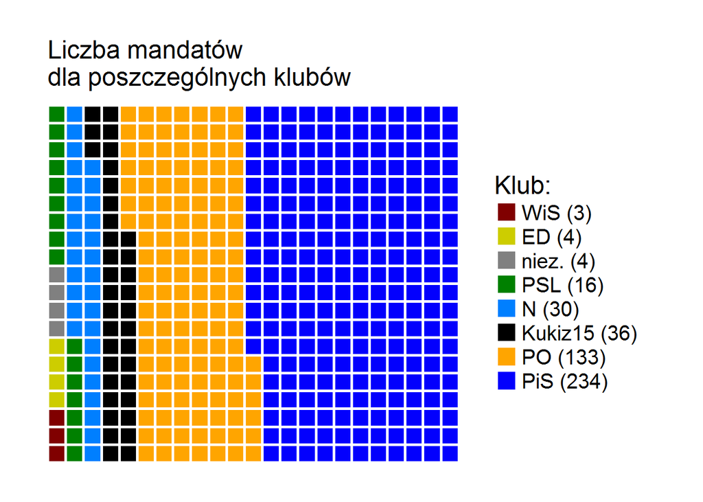

### Wykres 2

Kolejny wykres przedstawia procent nieobecności posłów na głosowaniach w zależności od klubów, do których należeli w dniu 04. 10. 2016 r.. Ze względu na utracenie przez kilku posłów ich mandatów (śmierć, pełnienie innych funkcji), nie wszyscy posłowie mogli stawić się na wszystkich 1912 głosowaniach. Z tego względu frakcję nieobecności poszczególnych osób obliczamy na podstawie liczby głosowań, w których realnie mogły one uczestniczyć. Dla każdego ugrupowania pionową czerwoną linią zaznaczyłyśmy średni procent nieobecności posłów z tego klubu, ponadto oznaczyłyśmy po jednej osobie z największym procentem nieobecności.

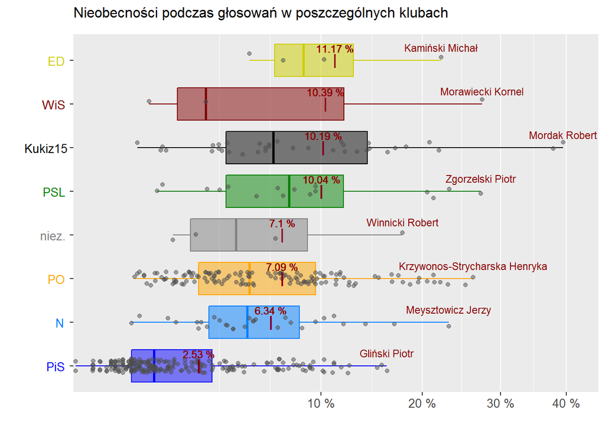

### Wykres 3

Ostatni wykres przedstawia posłów zmieniających klub w rozważanym okresie. Po najechaniu kursorem na poszczególne słupki otrzymujemy informację o tym, na ilu głosowaniach powinien być obecny, na ilu był nieobecny oraz procent nieobecności na głosowaniach w tym klubie.

[interactive chart not shown]

### Wnioski

Na podstawie powyższych wykresów możemy wytypować po jednej osobie z każdego klubu, która była najczęściej nieobecna na głosowaniach. Są to odpowiednio:

```
##        club                  surname_name count  ile procent   srednia
## 15  Kukiz15                 Mordak Robert   755 1912   39.49 10.190556
## 458     WiS             Morawiecki Kornel   525 1912   27.46 10.390000
## 453     PSL              Zgorzelski Piotr   522 1912   27.30 10.035625
## 346      PO Krzywonos-Strycharska Henryka   502 1912   26.26  7.092331
## 44        N             Meysztowicz Jerzy   443 1912   23.17  6.337000
## 4        ED               Kamiński Michał   425 1912   22.23 11.167500
## 71    niez.               Winnicki Robert   340 1912   17.78  7.100000
## 177     PiS                 Gliński Piotr   308 1912   16.11  2.534573
```

Ponadto można też zauważyć, że jedynie w klubie PiS są posłowie, którzy byli obecni na wszystkich głosowaniach:

```
##        surname_name club count
## 1 Gonciarz Jarosław  PiS     0
## 2    Kubiak Dariusz  PiS     0
## 3 Latosiński Bogdan  PiS     0
## 4       Polak Piotr  PiS     0
## 5     Warwas Robert  PiS     0
```

```
##        club                  surname_name count  ile procent   srednia
## 15  Kukiz15                 Mordak Robert   755 1912   39.49 10.190556
## 40  Kukiz15                    Wilk Jacek   725 1912   37.92 10.190556
## 458     WiS             Morawiecki Kornel   525 1912   27.46 10.390000
## 453     PSL              Zgorzelski Piotr   522 1912   27.30 10.035625
## 346      PO Krzywonos-Strycharska Henryka   502 1912   26.26  7.092331
## 313      PO          Małecka-Libera Beata   483 1912   25.26  7.092331
## 449     PSL             Pasławska Urszula   444 1912   23.22 10.035625
## 44        N             Meysztowicz Jerzy   443 1912   23.17  6.337000
## 366      PO           Korzeniowski Leszek   441 1912   23.06  7.092331
## 4        ED               Kamiński Michał   425 1912   22.23 11.167500
## 417      PO             Piotrowska Teresa   423 1912   22.12  7.092331
```

Średnio najczęściej nieobecni byli posłowie z klubu ED oraz WiS, ale należy zwrócić, że wysokość tych średnich jest uwarunkowana małą licznością tych klubów.

Można więc stwierdzić, że najczęściej na głosowaniach nie pojawiają się posłowie ugrupowania Kukiz’15, a najmniej nieobecności mają posłowie z PiS.

### Tabele

Powyższe wykresy zostały sporządzone na podstawie poniższych danych.

- Wykres 1 - liczba mandatów

```
##      club count
## 1     WiS     3
## 2      ED     4
## 3   niez.     4
## 4     PSL    16
## 5       N    30
## 6 Kukiz15    36
## 7      PO   133
## 8     PiS   234
```

- Wykres 2 - procent nieobecności na głosowaniach

```
##        club                  surname_name count  ile procent   srednia
## 1        ED           Niesiołowski Stefan   196 1912   10.25 11.167500
## 2        ED           Huskowski Stanisław    96 1912    5.02 11.167500
## 3        ED            Protasiewicz Jacek   137 1912    7.17 11.167500
## 4        ED               Kamiński Michał   425 1912   22.23 11.167500
## 5   Kukiz15                 Szramka Paweł    65 1912    3.40 10.190556
## 6   Kukiz15                Jakubiak Marek   273 1912   14.28 10.190556
## 7   Kukiz15            Liroy-Marzec Piotr   119 1912    6.22 10.190556
## 8   Kukiz15                    Apel Piotr   325 1912   17.00 10.190556
## 9   Kukiz15                Bakun Wojciech    12 1912    0.63 10.190556
## 10  Kukiz15              Ścigaj Agnieszka   115 1912    6.01 10.190556
## 11  Kukiz15              Kobylarz Andrzej    65 1912    3.40 10.190556
## 12  Kukiz15         Siarkowska Anna Maria   108 1912    5.65 10.190556
## 13  Kukiz15             Sachajko Jarosław    68 1912    3.56 10.190556
## 14  Kukiz15            Chruszcz Sylwester   347 1912   18.15 10.190556
```

[output cut: 446 more lines]

- Wykres 3 - procent nieobecności na głosowaniach - posłowie zmieniający kluby

```
##           surname_name    club count  ile procent kolejnosc
## 1  Huskowski Stanisław      ED     3   21   14.29         3
## 2  Huskowski Stanisław   niez.    11  138    7.97         2
## 3  Huskowski Stanisław      PO    82 1753    4.68         1
## 4         Jaros Michał       N    11  449    2.45         2
## 5         Jaros Michał      PO    55 1463    3.76         1
## 6      Kamiński Michał      ED     2   21    9.52         3
## 7      Kamiński Michał   niez.   122  138   88.41         2
## 8      Kamiński Michał      PO   301 1753   17.17         1
## 9         Klawiter Jan   niez.    29 1901    1.53         2
## 10        Klawiter Jan     PiS     1   11    9.09         1
## 11    Kobyliński Paweł Kukiz15    17  176    9.66         1
## 12    Kobyliński Paweł       N   150 1668    8.99         3
## 13    Kobyliński Paweł   niez.    61   68   89.71         2
## 14   Morawiecki Kornel Kukiz15   323 1088   29.69         1
## 15   Morawiecki Kornel     WiS   202  694   29.11         2
## 16 Niesiołowski Stefan      ED     1   21    4.76         2
## 17 Niesiołowski Stefan      PO   195 1891   10.31         1
## 18  Protasiewicz Jacek   niez.     8  138    5.80         2
## 19  Protasiewicz Jacek      PO   129 1753    7.36         1
## 20     Winnicki Robert Kukiz15   273 1090   25.05         1
## 21     Winnicki Robert   niez.    67  822    8.15         2
## 22 Zwiercan Małgorzata Kukiz15    15 1088    1.38         1
## 23 Zwiercan Małgorzata     WiS     2  694    0.29         2
## 24      Zyska Ireneusz Kukiz15    45 1218    3.69         1
## 25      Zyska Ireneusz     WiS     9  694    1.30         2
```